# Supermarket Customer Insight

Jacqueline Martinez

08/05/2023

# Supermarket Sales Analysis

Welcome to this comprehensive analysis of supermarket sales data, where we dive into the fascinating realm of customer behavior and trends! In this exploration, we journey through the intricate threads of product lines, branches, cities, membership statuses, and even genders, discovering valuable insights that will help guide us to create a better quality experience for our clients.

### Unveiling Insights into Customer Dynamics

Our aim is to uncover the hidden stories behind the numbers, to decipher the patterns that shape purchasing decisions and preferences. By scrutinizing the data on product lines, we gain a glimpse into what captures the imagination of our customers and ultimately unearth the geographical nuances that influence their shopping behaviors.

With each visualization, statistic, and correlation we uncover, we paint a vivid picture of the supermarket’s pulse, providing stakeholders and enthusiasts with a deep understanding of the market dynamics.

```r
library(tidyverse)
library(prophet)
library(readr)
library(lubridate)
library(forecast)
```

```r
library(ggplot2)
library(dplyr)
library(tibble)
library(scales)
library(plotly)
library(stringr)

# Load the dataset
supermarket_sales <- read_csv("Desktop/supermarket_sales.csv")
```

### Data Exploration

In this section, we start by exploring the structure and content of the dataset. We use various functions to understand the variables, their types, and basic summary statistics. By visualizing the initial records, we get a glimpse of the data we’re working with.

```r
str(supermarket_sales)
```

```
## spc_tbl_ [1,000 × 17] (S3: spec_tbl_df/tbl_df/tbl/data.frame)
##  $ Invoice ID             : chr [1:1000] "750-67-8428" "226-31-3081" "631-41-3108" "123-19-1176" ...
##  $ Branch                 : chr [1:1000] "A" "C" "A" "A" ...
##  $ City                   : chr [1:1000] "Yangon" "Naypyitaw" "Yangon" "Yangon" ...
##  $ Customer Type          : chr [1:1000] "Member" "Normal" "Normal" "Member" ...
##  $ Gender                 : chr [1:1000] "Female" "Female" "Male" "Male" ...
##  $ Product line           : chr [1:1000] "Health and beauty" "Electronic accessories" "Home and lifestyle" "Health and beauty" ...
##  $ Unit price             : chr [1:1000] "$74.69" "$15.28" "$46.33" "$58.22" ...
##  $ Quantity               : num [1:1000] 7 5 7 8 7 7 6 10 2 3 ...
##  $ Tax 5%                 : chr [1:1000] "$26.14" "$3.82" "$16.22" "$23.29" ...
##  $ Total                  : chr [1:1000] "$548.97" "$80.22" "$340.53" "$489.05" ...
##  $ Date                   : Date[1:1000], format: "2019-01-05" "2019-03-08" ...
##  $ Time                   : 'hms' num [1:1000] 13:08:00 10:29:00 13:23:00 20:33:00 ...
##   ..- attr(*, "units")= chr "secs"
##  $ Payment                : chr [1:1000] "Ewallet" "Cash" "Credit card" "Ewallet" ...
##  $ COGS                   : chr [1:1000] "$522.83" "$76.40" "$324.31" "$465.76" ...
##  $ Gross Margin Percentage: num [1:1000] 4.76 4.76 4.76 4.76 4.76 ...
##  $ Gross Income           : num [1:1000] 26.14 3.82 16.22 23.29 30.21 ...
##  $ Rating                 : num [1:1000] 9.1 9.6 7.4 8.4 5.3 4.1 5.8 8 7.2 5.9 ...
##  - attr(*, "spec")=
##   .. cols(
##   ..   `Invoice ID` = col_character(),
##   ..   Branch = col_character(),
##   ..   City = col_character(),
##   ..   `Customer Type` = col_character(),
##   ..   Gender = col_character(),
##   ..   `Product line` = col_character(),
##   ..   `Unit price` = col_character(),
##   ..   Quantity = col_double(),
##   ..   `Tax 5%` = col_character(),
##   ..   Total = col_character(),
##   ..   Date = col_date(format = ""),
##   ..   Time = col_time(format = ""),
##   ..   Payment = col_character(),
##   ..   COGS = col_character(),
##   ..   `Gross Margin Percentage` = col_double(),
##   ..   `Gross Income` = col_double(),
##   ..   Rating = col_double()
##   .. )
##  - attr(*, "problems")=<externalptr>
```

```r
summary(supermarket_sales)
```

```
##   Invoice ID           Branch              City           Customer Type
##  Length:1000        Length:1000        Length:1000        Length:1000
##  Class :character   Class :character   Class :character   Class :character
##  Mode  :character   Mode  :character   Mode  :character   Mode  :character
##
##
##
##     Gender          Product line        Unit price           Quantity
##  Length:1000        Length:1000        Length:1000        Min.   : 1.00
##  Class :character   Class :character   Class :character   1st Qu.: 3.00
##  Mode  :character   Mode  :character   Mode  :character   Median : 5.00
##                                                           Mean   : 5.51
##                                                           3rd Qu.: 8.00
##                                                           Max.   :10.00
##     Tax 5%             Total                Date                Time
##  Length:1000        Length:1000        Min.   :2019-01-01   Length:1000
##  Class :character   Class :character   1st Qu.:2019-01-24   Class1:hms
##  Mode  :character   Mode  :character   Median :2019-02-13   Class2:difftime
##                                        Mean   :2019-02-14   Mode  :numeric
##                                        3rd Qu.:2019-03-08
##                                        Max.   :2019-03-30
##    Payment              COGS           Gross Margin Percentage  Gross Income
##  Length:1000        Length:1000        Min.   :4.762           Min.   : 0.510
##  Class :character   Class :character   1st Qu.:4.762           1st Qu.: 5.928
##  Mode  :character   Mode  :character   Median :4.762           Median :12.090
##                                        Mean   :4.762           Mean   :15.380
##                                        3rd Qu.:4.762           3rd Qu.:22.445
##                                        Max.   :4.762           Max.   :49.650
##      Rating
##  Min.   : 4.000
##  1st Qu.: 5.500
##  Median : 7.000
##  Mean   : 6.973
##  3rd Qu.: 8.500
##  Max.   :10.000
```

```r
head(supermarket_sales)
```

```
## # A tibble: 6 × 17
##   `Invoice ID` Branch City    `Customer Type` Gender `Product line` `Unit price`
##   <chr>        <chr>  <chr>   <chr>           <chr>  <chr>          <chr>
## 1 750-67-8428  A      Yangon  Member          Female Health and be… $74.69
## 2 226-31-3081  C      Naypyi… Normal          Female Electronic ac… $15.28
## 3 631-41-3108  A      Yangon  Normal          Male   Home and life… $46.33
## 4 123-19-1176  A      Yangon  Member          Male   Health and be… $58.22
## 5 373-73-7910  A      Yangon  Normal          Male   Sports and tr… $86.31
## 6 699-14-3026  C      Naypyi… Normal          Male   Electronic ac… $85.39
## # ℹ 10 more variables: Quantity <dbl>, `Tax 5%` <chr>, Total <chr>,
## #   Date <date>, Time <time>, Payment <chr>, COGS <chr>,
## #   `Gross Margin Percentage` <dbl>, `Gross Income` <dbl>, Rating <dbl>
```

### Data Visualization and Analysis

### Total Sales by Branch

Here, we investigate the total sales across different branches over time. Through a line chart, we examine the sales trends for each branch individually, revealing any distinctive patterns or anomalies.

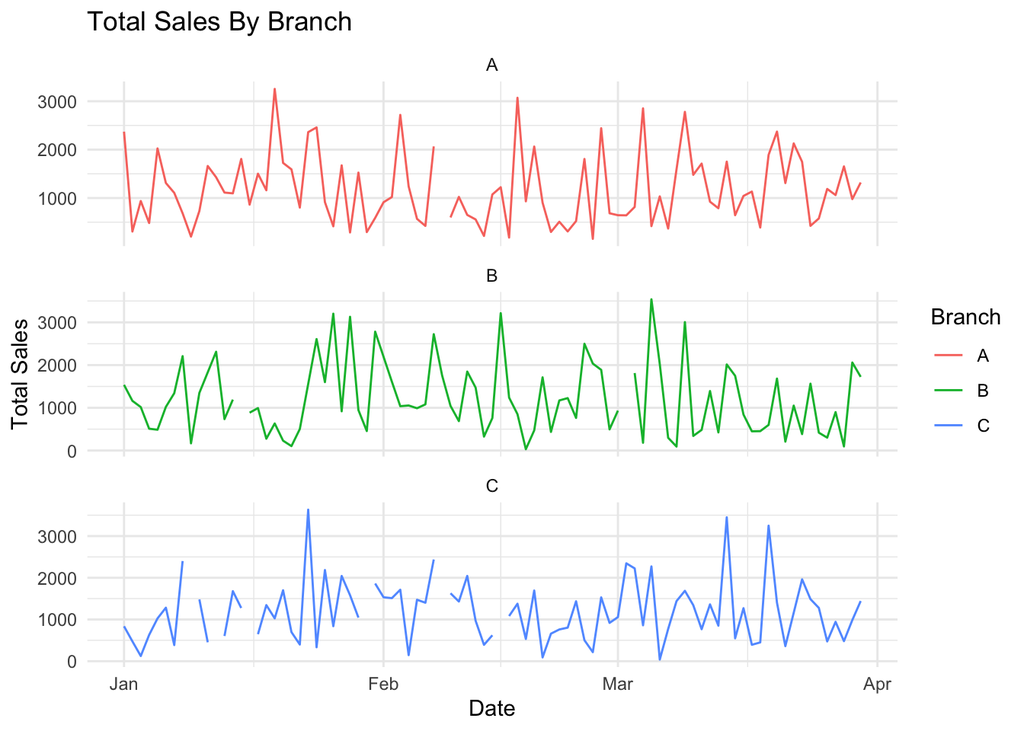

Total Sales by Branch

### Popularity of Types of Payments

In this section, we focus on the types of payments used by customers. A bar chart showcases the popularity of each payment method, giving insights into preferred payment options.

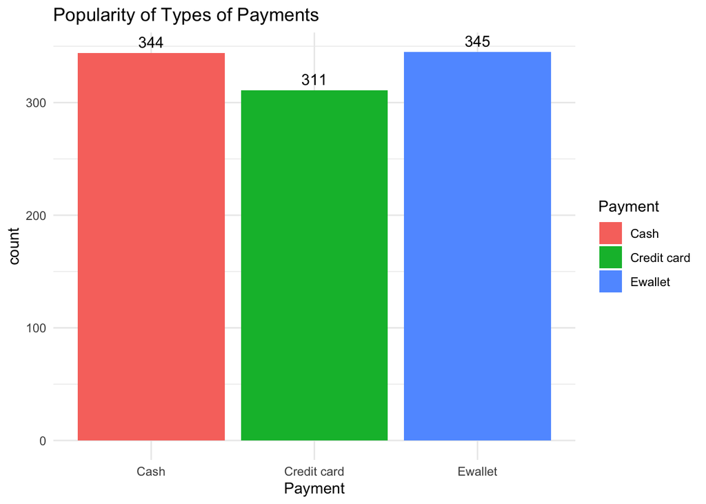

Popularity of Types of Payments

### Total Quantity of Sales by Gender

This section delves into the quantity of products sold based on gender. A bar chart demonstrates the gender-wise distribution of sales quantity.

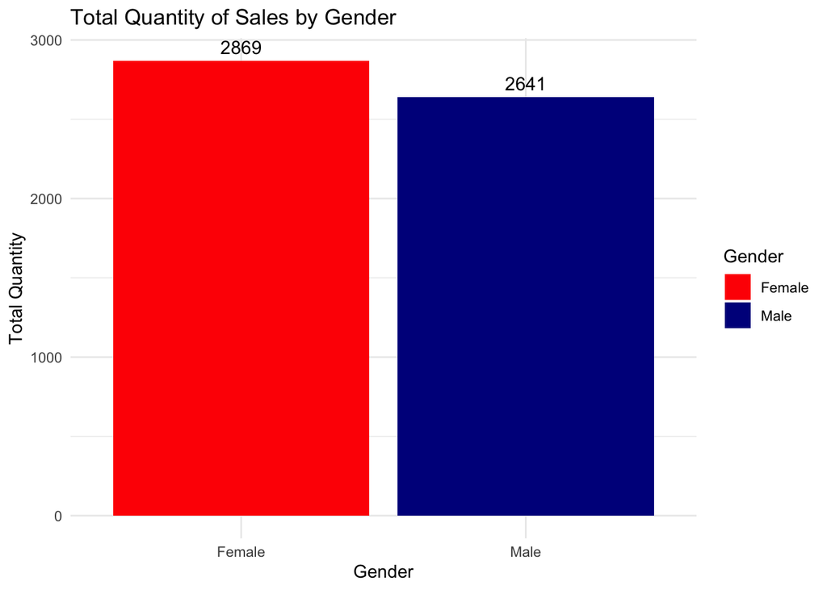

Total Quantity of Sales by Gender

### Sale by Product Line

Here, we analyze the sales distribution across different product lines. A bar chart illustrates the quantity of products sold for each product line.

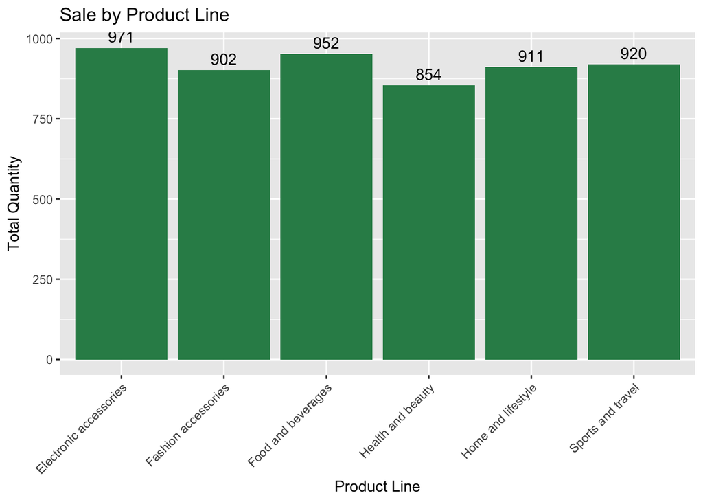

Sale By Product Line

### Quantity of Product Line Purchase by Gender

This section combines product line and gender information to explore how different genders engage with various product lines. A grouped bar chart highlights the sales quantity for each product line, categorized by gender.

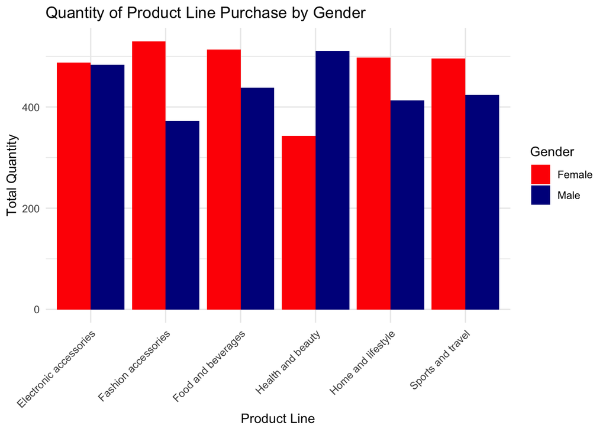

Quantity of Product Line Purchase by Gender

### Customer Type by Gender

In this section, we investigate the relationship between customer type (member or normal) and gender. A dodged bar chart reveals the distribution of customer types based on gender.

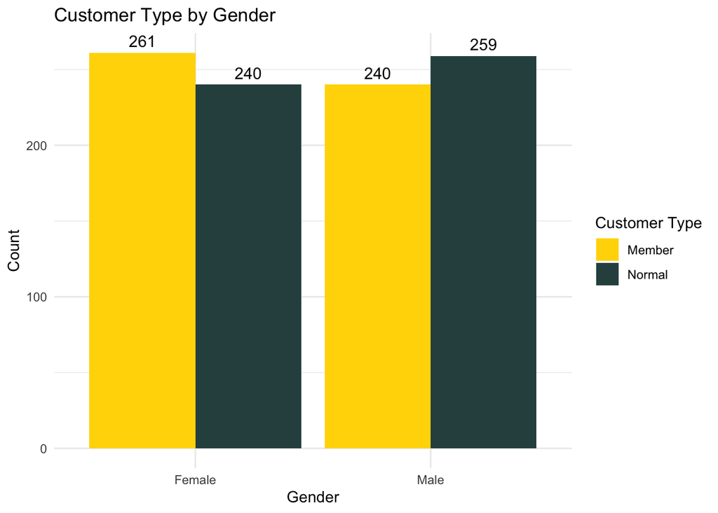

Customer Type by Gender

### Customer Type by Branch

Here, we explore the distribution of customer types across different branches. A dodged bar chart provides insights into the membership status of customers in each branch.

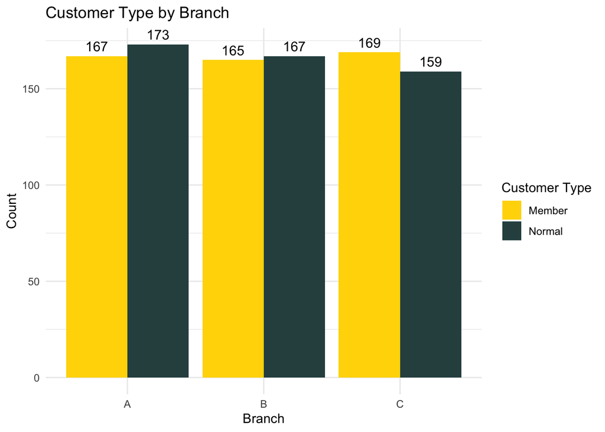

Customer Type by Branch

### Gross Income by Branch

This section focuses on the gross income generated by each branch. A bar chart showcases the total gross income for each branch.

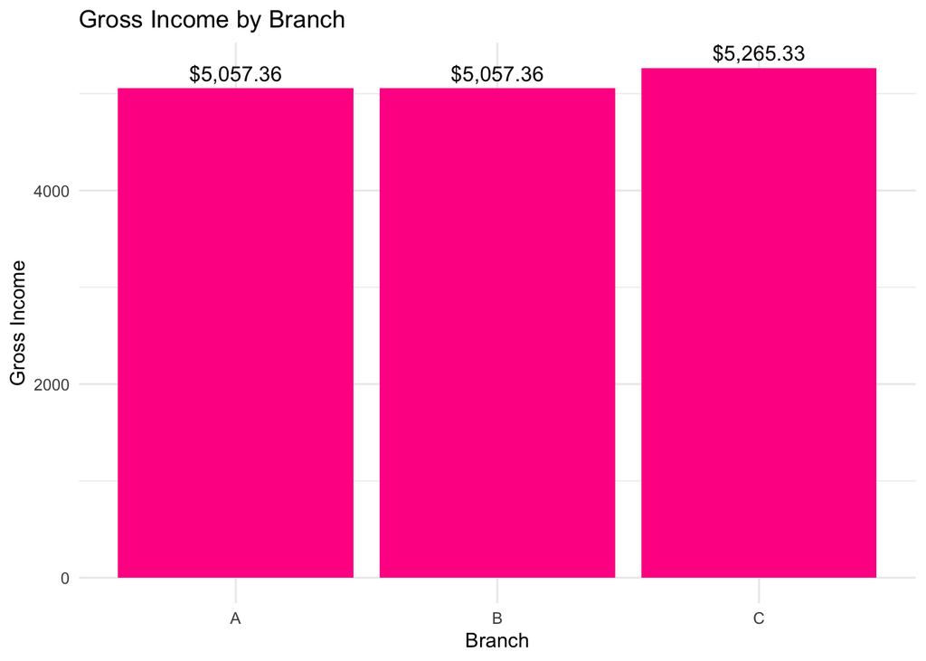

Gross Income by Branch

### Gross Income for Each Product Line

In this part, we delve into the gross income generated by each product line. A bar chart illustrates the total gross income associated with each product line.

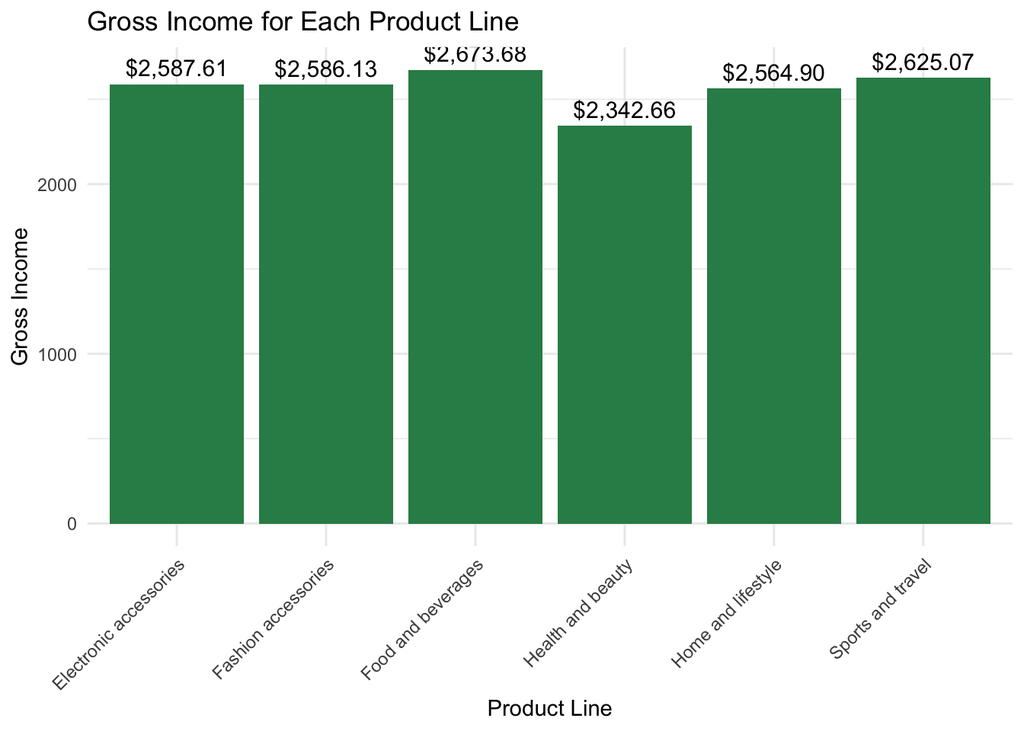

Gross Income for Each Product Line

### Quantity of Product Line Sold per City

Here, we explore the distribution of product line sales across different cities. A bar chart reveals the sales quantity for each product line within each city.

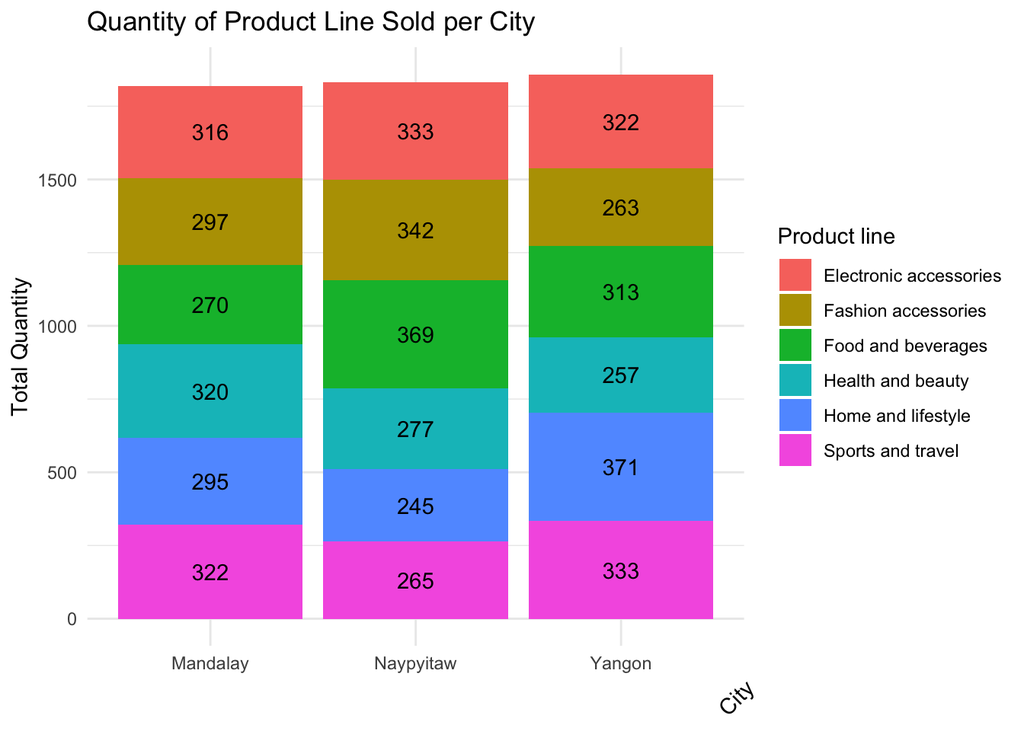

Quantity of Product Line Sold per City

### Monthly Profit from Total Gross Income

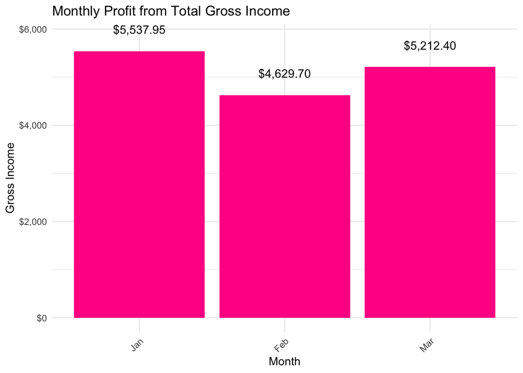

Montly Profit from Total Gross Income

### Total Sales Over Time

Here, we examine the total sales trends over time. A line chart illustrates the variations in total sales as time progresses.

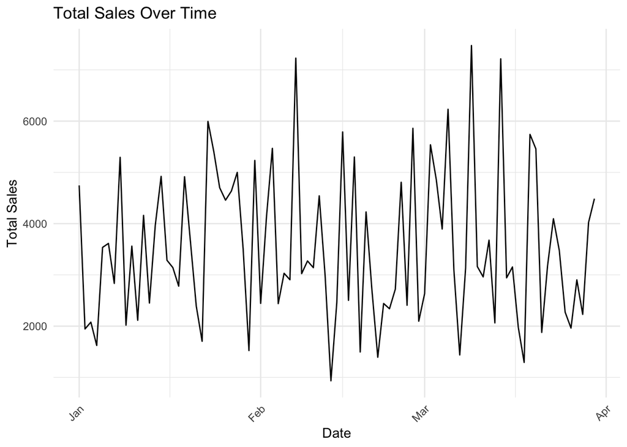

Total Sales Over Time

### Average Rating per Branch

In this section, we delve into the average ratings of branches. A bar chart reveals the average rating of each branch.

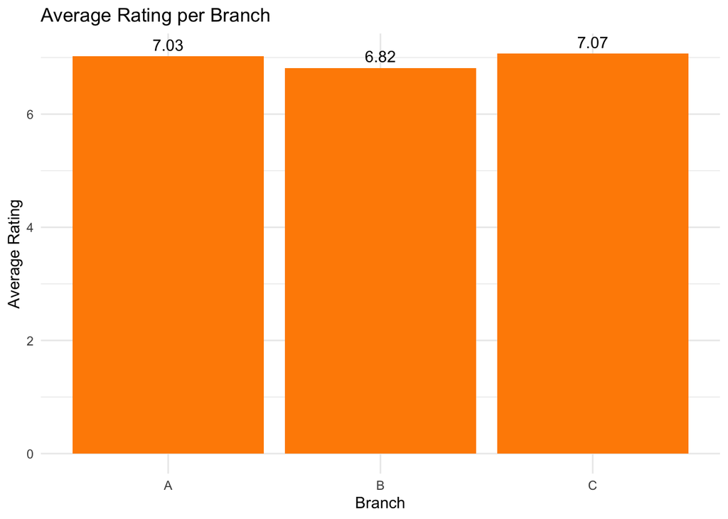

Average Rating per Branch

### Average Rating per City

Here, we explore the average ratings of cities. A bar chart showcases the average rating of each city.

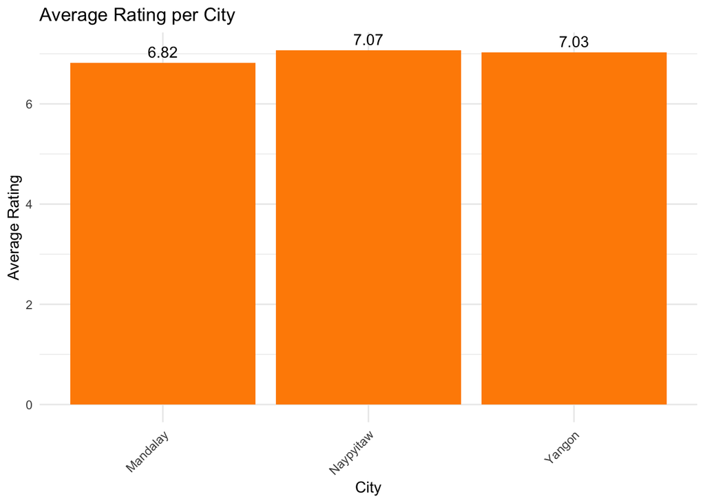

Average Rating per City

### Average Rating per Product Line

In this part, we investigate the average ratings of different product lines. A bar chart reveals the average rating for each product line.

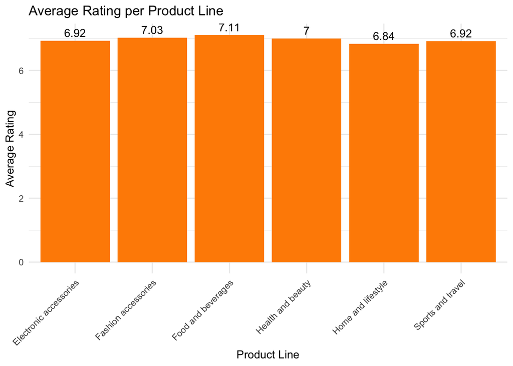

Average Rating per Product Line

### Sales and April Forecast

Here, we predict the sales forecast for the upcoming month of April. Using the ‘prophet’ package, we generate a forecast and visualize it alongside the historical sales data.

```
## Disabling yearly seasonality. Run prophet with yearly.seasonality=TRUE to override this.
```

```
## Disabling daily seasonality. Run prophet with daily.seasonality=TRUE to override this.
```

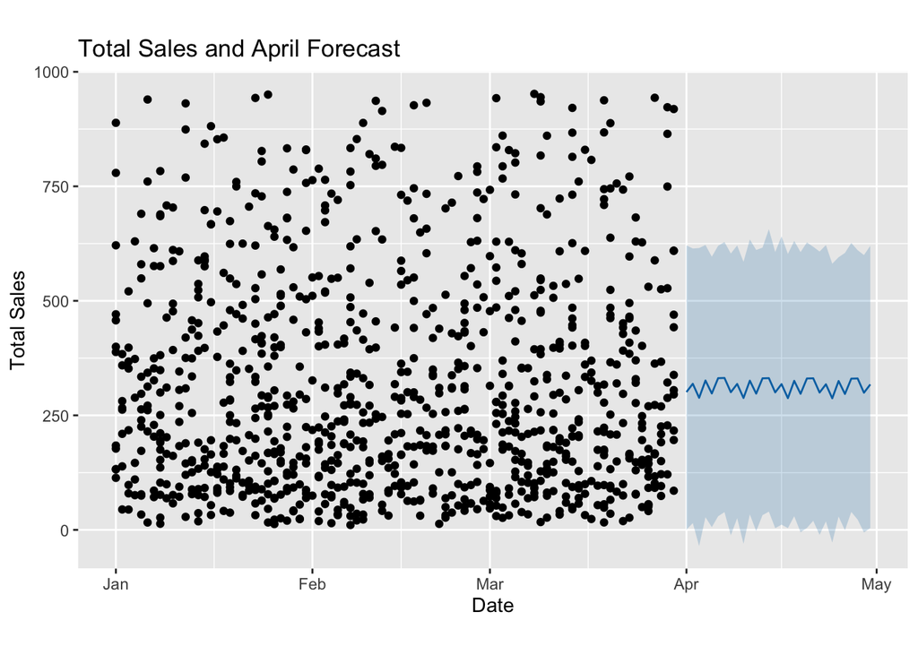

Total Sales and April Forecast

[output not shown]

[output cut: 109 more lines]

## Conclusion

In this analysis, we’ve unraveled a wealth of insights from supermarket sales data, shedding light on customer behavior and trends. Each visualization and exploration piece contributes to our understanding of the market dynamics. Here are some actionable recommendations to consider:

- **Payment Methods:** Given the popularity of Cash and Ewallet payments, ensuring streamlined and secure transactions in these modes can enhance customer convenience.
- **Sale by Product Line:** The popularity of Electronic accessories and Food and Beverages indicates potential for diversifying the Health and Beauty product line. Adjusting offerings to meet customer preferences can be explored.
- **Customer Type by Gender:** Female customers are more likely to be Members, while male customers are more often Non-members.
- **Branch-Specific Enhancements:** Branch C’s higher gross income underscores its performance. Sharing best practices from Branch C with the other branches might help uplift overall performance.
- **City-Specific Strategies:** Tailoring product offerings to match city-specific preferences, such as Naypyitaw’s inclination towards Food and Beverages and Yangon’s broader interest in Sports and travel, can enhance regional sales.
- **Enhancing Ratings:** Focusing on Branch B’s ratings can potentially raise its performance, while replicating Naypyitaw’s high average rating can uplift the overall brand image.
- **Sales Forecast:** April’s sales forecast resembles March’s, suggesting stability but no notable growth. Therefore, leveraging insights into customer behavior can guide strategies to create more personalized and engaging shopping experiences to lead to more growth.